# Generate a spectral scene from an RGB image

ISETCam has methods to create spectral scenes from RGB file.

The basic idea implemented in ISETCam is this: We read the RGB image from the file, and we then assume the RGB data are shown on a specific calibrated display. This will produce spectral radiance from the display. We use those spectral radiances to defeine the scene. We assume that the illuminant is the display white point.

This produces an accurate result if we are really using a display. But we may want to produce a scene that has more natural illuminant and reflectances. To achieve that, we adjust the scene illuminant to a natural illuminant, such as D65.

## Contents

- Initialize - image file and example displays
- Create a scene from a file assuming an OLED display
- Adjust the illuminant
- Show scene on LCD
- Show scene on CRT
- Compare the three images
- Compare the three monitor gamuts
- The reflectance-display

## Initialize - image file and example displays

```matlab
ieInit;

imgFileName = 'macbeth.tif';

dispOLEDFile = 'OLED-Sony.mat';
dispLCDFile = 'LCD-Apple.mat';
dispCRTFile = 'CRT-Dell.mat';
```

## Create a scene from a file assuming an OLED display

The illuminant is set to be the white point of the monitor. In this format, the surface reflectances are not typical.

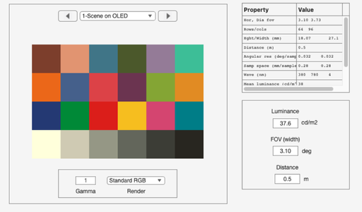

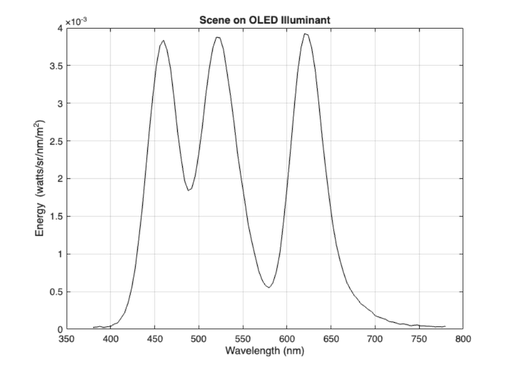

```matlab
sceneA = sceneFromFile(imgFileName,'rgb',[],dispOLEDFile);
sceneA = sceneSet(sceneA,'name','Scene on OLED');
ieAddObject(sceneA); sceneWindow;
scenePlot(sceneA,'illuminant energy');
```

## Adjust the illuminant

The scene is rendered with an illuminant equal to the white point of the display. This is not a natural illuminant, and we can adjust the illuminant to a more natural one this way.

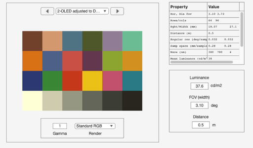

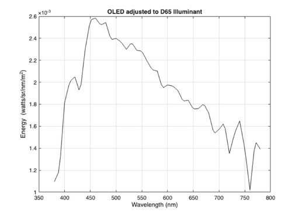

```matlab
sceneA = sceneAdjustIlluminant(sceneA,'D65.mat');
sceneA = sceneSet(sceneA,'name','OLED adjusted to D65');
ieAddObject(sceneA); sceneWindow;
scenePlot(sceneA,'illuminant energy');
```

The result of this transformation is not only to change the illuminant. It also changes the implicit surface reflectances, making them more similar to natural reflectances.

Below we describe a better way to achieve this that is particularly valuable when reading in an RGB image with unknown origin. For comparison, here is the reflectance of the green patch. This is a pretty unlikely reflectance - though it is consistent with the data.

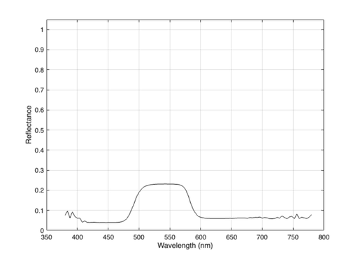

```matlab
greenRect = [21    34     8    11];
scenePlot(sceneA,'reflectance',greenRect);
```

## Show scene on LCD

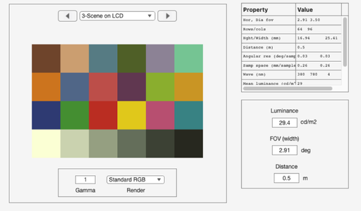

```matlab
sceneB = sceneFromFile(imgFileName,'rgb',[],dispLCDFile);
sceneB = sceneSet(sceneB,'name','Scene on LCD');
ieAddObject(sceneB); sceneWindow;
```

## Show scene on CRT

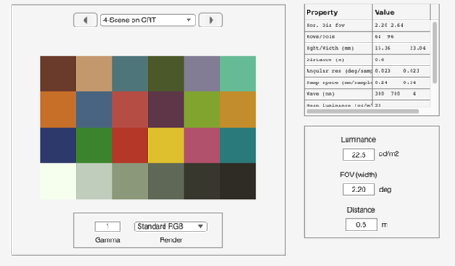

```matlab
sceneC = sceneFromFile(imgFileName,'rgb',[],dispCRTFile);
sceneC = sceneSet(sceneC,'name','Scene on CRT');
ieAddObject(sceneC); sceneWindow;
```

## Compare the three images

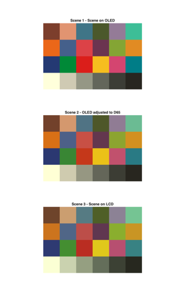

```matlab
imageMultiview('scene', 1:3, true);
```

## Compare the three monitor gamuts

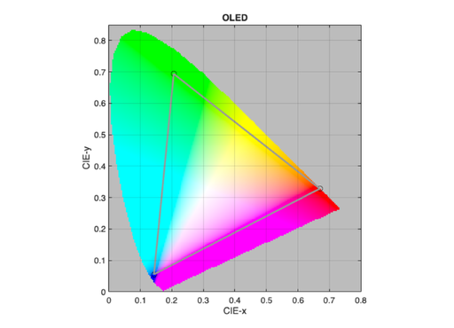

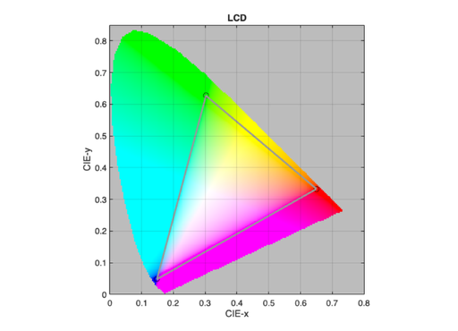

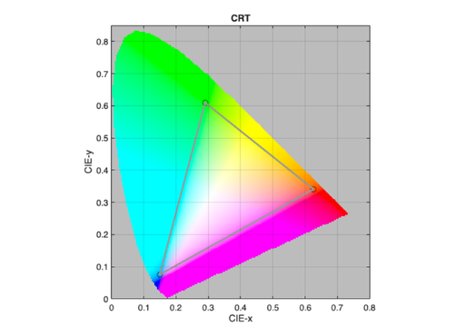

```matlab
d = displayCreate(dispOLEDFile);
displayPlot(d,'gamut');
title('OLED')

d = displayCreate(dispLCDFile);
displayPlot(d,'gamut');
title('LCD')

d = displayCreate(dispCRTFile);
displayPlot(d,'gamut');
title('CRT')
```

## The reflectance-display

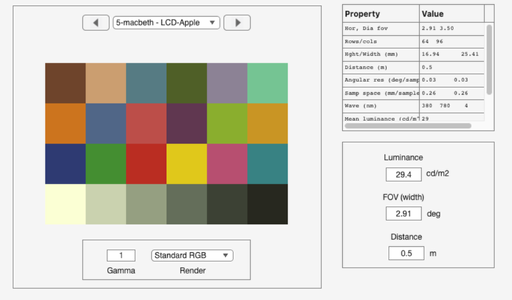

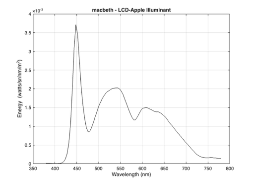

```matlab
d = displayCreate;
sceneD = sceneFromFile(imgFileName,'rgb',[],d);
ieAddObject(sceneD); sceneWindow;
scenePlot(sceneD,'illuminant energy');
```

Here is the estimate for the green chip surface reflectance, which is consistent with natural surfaces.

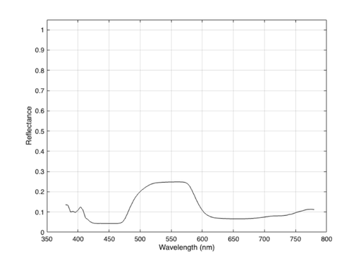

```matlab
scenePlot(sceneD,'reflectance',greenRect);
```

[Published with MATLAB® R2025b](https://www.mathworks.com/products/matlab/)